# DAT301 Final Project

## Braeden Burgard, Sabrina Vo & Peyton Lewis

We are analyzing **what factors go into a good movie rating**. Data comes from the rest API of omdp.

Movies chosen by https://en.wikipedia.org/wiki/List_of_highest-grossing_films and https://www.imdb.com/list/ls055592025/. Movies have been selected through a combination of top grossing, classic, and random (for control) categories. **What factors have led to the highest rated movies being so highly rated?**

```python
# Import Libraries
import numpy as np
import pandas as pd
import matplotlib.pyplot as plt
import urllib.request, json
import seaborn as sns
from matplotlib.lines import Line2D
import matplotlib
from mpl_toolkits.mplot3d import Axes3D
```

```python
#this enables interactive use of matplotlib
##%matplotlib notebook
%matplotlib inline
```

```python
movies = ["The+Lorax", "The+incredibles", "Avengers:+endgame", "Avatar",
           "Titanic", "Avengers:+infinity+war",
           "The+lion+king", "The+avengers", "Furious+7", "Frozen+ii",
           "Avengers:+age+of+ultron", "Black+panther", "Frozen", "Beauty+and+the+beast",
           "Incredibles+2", "The+fate+of+the+furious", "Iron+man+3", "Minions",
           "Captain+america:+civil+war", "aquaman", "The+lord+of+the+rings:+the+return+of+the+king",
           "Spider-man:+far+from+home", "Captain+marvel", "Transformers:+dark+of+the+moon",
           "Skyfall", "Transformers:+age+of+extinction", "The+dark+knight+rises",
           "Joker", "Toy+story+4", "Toy+story+3", "The+godfather",
           "The+shawshank+redemption", "Schindler's+list", "Raging+bull",
           "Casablanca", "Gone+with+the+wind", "One+flew+over+the+cuckoo's+nest",
           "Psycho", "On+the+waterfront","Forrest+gump", "The+sound+of+music",
           "West+side+story", "The+pacifier", "Enchanted", "Diary+of+a+wimpy+kid",
           "The+social+network", "Aquamarine", "Epic+movie", "Maze+runner", "Fury",
           "Guardians+of+the+galaxy", "Gone+girl", "The+imitation+game",
           "Last+vegas", "The+green+mile", "Sleepless+in+seattle", "The+wolf+of+wall+street",
           "The+grey", "Cloudy+with+a+chance+of+meatballs"]

numimdb = 0
numRottenTomatoes = 0
numMetacritic = 0
ratings = pd.DataFrame(0,
                  index=np.arange(len(movies)),
                  columns=pd.Index(['imdb', 'Metacritic'], name='Title'))
ratings.index = movies
ratings

movieInfo = pd.DataFrame(0,
                         index=np.arange(len(movies)),
                         columns=pd.Index(['Year', 'Rated', 'Released', 'Runtime', 'Director', 'Writer', 'Genre']
                                          , name='Title'))
movieInfo.index = movies


genres = ["Action","Adventure","Animation","Comedy","Crime","Drama","Family",
          "Fantasy","Musical","Romance","Sci-Fi","Thriller","War"]

genreRatings = pd.DataFrame(0,
                            index=np.arange(3),
                            columns=pd.Index(genres))
genreRatings.index = ['imdb', 'Rotten Tomatoes', 'Metacritic']
genreRatings

numGenreRatings = pd.DataFrame(0,
                            index=np.arange(3),
                            columns=pd.Index(genres))
numGenreRatings.index = ['imdb', 'Rotten Tomatoes', 'Metacritic']
numGenreRatings


#This should be 1 to length(movies) but I changed it to run faster
for i in range(0, len(movies)):
    aurl = "http://www.omdbapi.com/?t=" + movies[i] + "&r=json&apikey=f73c99fb"
    with urllib.request.urlopen(aurl) as url:
        dictdata = json.loads(url.read().decode())
        data = pd.DataFrame.from_dict(dictdata, orient='index')

    movieInfo.iloc[i,0] = dictdata['Year']
    movieInfo.iloc[i,1] = dictdata['Rated']
    movieInfo.iloc[i,2] = dictdata['Released']
    movieInfo.iloc[i,3] = dictdata['Runtime']
    movieInfo.iloc[i,4] = dictdata['Director']
    movieInfo.iloc[i,5] = dictdata['Writer']
    movieInfo.iloc[i,6] = dictdata['Genre']

    ratings.iloc[i,1] = dictdata['Metascore']
    ratings.iloc[i,0] = dictdata['imdbRating']
```

```python
genres = ["Action","Adventure","Animation","Comedy","Crime","Drama","Family",
          "Fantasy","Musical","Romance","Sci-Fi","Thriller","War"]

genreRatings = pd.DataFrame(0,
                            index=np.arange(2),
                            columns=pd.Index(genres))
genreRatings.index = ['imdb', 'Metacritic']

numGenreRatings = pd.DataFrame(0,
                            index=np.arange(2),
                            columns=pd.Index(genres))
numGenreRatings.index = ['imdb', 'Metacritic']

#fill up the genreRatings arrays
for i in range(0,len(movies)):
    for genre in movieInfo.iloc[:,6][i].split(", "):
        #inside of try block, in case genre isn't in the list it won't fail
        try:
            genreRatings.loc['imdb',genre] = float(genreRatings.loc['imdb',genre]) + (float(ratings.iloc[i,0]) * 10)
            numGenreRatings.loc['imdb',genre] = float(numGenreRatings.loc['imdb',genre]) + 1
            genreRatings.loc['Metacritic',genre] = float(genreRatings.loc['Metacritic',genre]) + float(ratings.iloc[i,1])
            numGenreRatings.loc['Metacritic',genre] = float(numGenreRatings.loc['Metacritic',genre]) + 1
        except:
            x = "This is here for compilation only"

#calculate average genre ratings
for genre in genres:
    genreRatings.loc['imdb',genre] = float(genreRatings.loc['imdb',genre]) / float(numGenreRatings.loc['imdb',genre])
    genreRatings.loc['Metacritic',genre] = float(genreRatings.loc['Metacritic',genre]) / float(numGenreRatings.loc['Metacritic',genre])
```

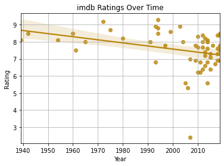

```python
#ratings over time

#imdb
#convert ratings and year into float
imdb_rating = ratings.iloc[:,0]
meta_rating = ratings.iloc[:,1]
y = []
k = []
for i in range(0,len(imdb_rating)):
    y.append(float(imdb_rating[i]))
    k.append(float(meta_rating[i]))

year = movieInfo.iloc[:,0]
x = []
for i in range(0,len(year)):
    x.append(float(year[i]))
#plot
df = [x, k ,y]
sns.regplot(x, y, data=df, ci=95, color='darkgoldenrod')
plt.title('imdb Ratings Over Time')
plt.xlabel('Year')
plt.ylabel('Rating')
plt.grid()
```

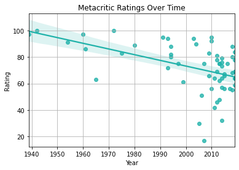

```python
#metacritic ratings over time
sns.regplot(x, k, data=df, ci=95, color="lightseagreen")
plt.title("Metacritic Ratings Over Time")
plt.xlabel('Year')
plt.ylabel('Rating')
plt.grid()
```

- As seen in both graphs, we can conclude that movie ratings have decreased over time
- It is important to note that there have been an increase of movie production from 2000-2020
  - This raises the question: Are movie ratings decreasing over time because there is more competition?

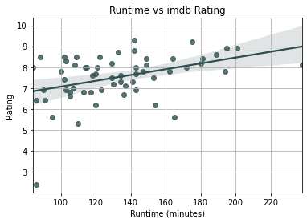

```python
#length of movie vs rating
#imdb
#convert runtime into float
time = movieInfo.iloc[:,3]
t = []
for i in time:
    t.append(float(i[:3]))

#plot
df2 = [t, y, k]
sns.regplot(t,y, data=df2, ci=95, color='darkslategrey')
plt.title('Runtime vs imdb Rating')
plt.xlabel('Runtime (minutes)')
plt.ylabel('Rating')
plt.grid()
```

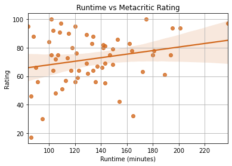

```python
sns.regplot(t, k, data=df2, ci=95, color="chocolate")
plt.title('Runtime vs Metacritic Rating')
plt.xlabel('Runtime (minutes)')
plt.ylabel('Rating')
plt.grid()
```

- As seen in the best fit line from both graphs, movie ratings increase as runtime increases
- From the imdb graph we can conclude that most movies range from 100mins - 160mins
- In the metacritic graph we can see that there are many outliers, suggesting that runtime is not an important factor for metacritic ratings

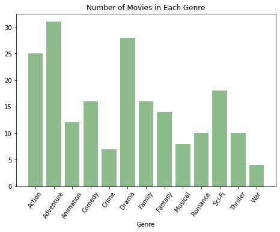

```python
#num of movies in each genre
fig = plt.figure()
ax = fig.add_axes([0,0,1,1])
ax.bar(genres,numGenreRatings.iloc[1,:], color='darkseagreen')
plt.xticks(rotation=55)
plt.title('Number of Movies in Each Genre')
plt.xlabel('Genre')
plt.show()
```

- The most commonly produced movies are adventure followed by drama
- The least commonly produced movies are war

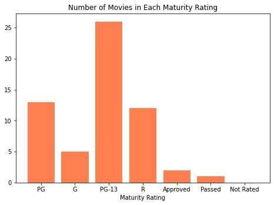

```python
#num of movies in maturity rating

pg = 0
g = 0
pg_13 = 0
r = 0
approved = 0
passed = 0
not_rated = 0
for i in range(0,len(movies)):
    if (movieInfo.iloc[i,1]=="PG"):
        pg = pg+1
    if (movieInfo.iloc[i,1]=="G"):
        g = g+1
    if (movieInfo.iloc[i,1]=="PG-13"):
        pg_13 = pg_13+1
    if (movieInfo.iloc[i,1]=="R"):
        r = r+1
    if (movieInfo.iloc[i,1]=="Approved"):
        approved = approved+1
    if (movieInfo.iloc[i,1]=="Passed"):
        passed = passed+1
    if (movieInfo.iloc[i,1]=="Not Rated"):
        not_rated = not_rated+1
num_ratings = [pg, g, pg_13, r, approved, passed, not_rated]
name_ratings = ["PG", "G", "PG-13", "R", "Approved", "Passed", "Not Rated"]

fig = plt.figure()
ax = fig.add_axes([0,0,1,1])
ax.bar(name_ratings, num_ratings, color="coral")
plt.title("Number of Movies in Each Maturity Rating")
plt.xlabel("Maturity Rating")
plt.show()
```

- The most commonly produced movies are PG-13
- From the pervious graph, we can conclude that adventure movies rated PG-13 are the most commonly produced moives

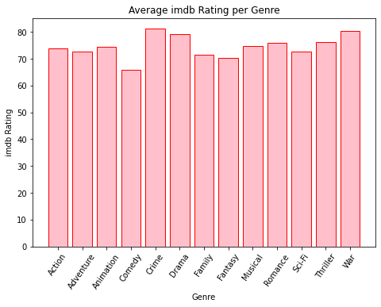

```python
# Average imdb Rating per Genre
fig = plt.figure()
ax = fig.add_axes([0,0,1,1])
ax.bar(genres,genreRatings.iloc[0,:], color='pink', edgecolor='red')
plt.xticks(rotation=55)
plt.title('Average imdb Rating per Genre')
plt.xlabel('Genre')
plt.ylabel('imdb Rating')
plt.show()
```

- The average imdb rating is consistent across all genres
- However crime movies seem to have the highest mean imdb rating

[figure not shown]

```python
# Average Metacritic Rating per Genre
fig = plt.figure()
ax = fig.add_axes([0,0,1,1])
ax.bar(genres,genreRatings.iloc[1,:], color='yellow', edgecolor='orange')
plt.xticks(rotation=55)
plt.title('Average Metacritic Rating per Genre')
plt.xlabel('Genre')
plt.ylabel('Metacritic Rating')
plt.show()
```

```python
movieInfo['Year'] = movieInfo.Year.astype(int)
decades = ['1930', '1940', '1950', '1960', '1970', '1980', '1990',
                '2000', '2010']
genreMoviesYear = pd.DataFrame(0,
                  index=np.arange(9),
                  columns=pd.Index(genres))
genreMoviesYear.index = decades
```

```python
actionCount = 0
adventureCount = 0
animationCount = 0
comedyCount = 0
crimeCount = 0
dramaCount = 0
familyCount = 0
fantasyCount = 0
musicalCount = 0
romanceCount = 0
scifiCount = 0
thrillerCount = 0
warCount = 0



for i in range(0,len(movies)):
    if (movieInfo.iloc[i,0] >= 1930 and movieInfo.iloc[i,0] < 1940):
        k = 0
    elif (movieInfo.iloc[i,0] >= 1940 and movieInfo.iloc[i,0] < 1950):
        k = 1
    elif (movieInfo.iloc[i,0] >= 1950 and movieInfo.iloc[i,0] < 1960):
        k = 2
    elif (movieInfo.iloc[i,0] >= 1960 and movieInfo.iloc[i,0] < 1970):
        k = 3
    elif (movieInfo.iloc[i,0] >= 1970 and movieInfo.iloc[i,0] < 1980):
        k = 4
    elif (movieInfo.iloc[i,0] >= 1980 and movieInfo.iloc[i,0] < 1990):
        k = 5
    elif (movieInfo.iloc[i,0] >= 1990 and movieInfo.iloc[i,0] < 2000):
        k = 6
    elif (movieInfo.iloc[i,0] >= 2000 and movieInfo.iloc[i,0] < 2010):
        k = 7
    elif (movieInfo.iloc[i,0] >= 2010 and movieInfo.iloc[i,0] < 2020):
        k = 8

    if 'Action' in movieInfo.iloc[i,6]:
        actionCount = actionCount+1
        genreMoviesYear.iloc[k,0] = actionCount
    if 'Adventure' in movieInfo.iloc[i,6]:
        adventureCount = adventureCount+1
        genreMoviesYear.iloc[k,1] = adventureCount
    if 'Animation' in movieInfo.iloc[i,6]:
        animationCount = animationCount+1
        genreMoviesYear.iloc[k,2] = animationCount
    if 'Comedy' in movieInfo.iloc[i,6]:
        comedyCount = comedyCount+1
        genreMoviesYear.iloc[k,3] = comedyCount
    if 'Crime' in movieInfo.iloc[i,6]:
        crimeCount = crimeCount+1
        genreMoviesYear.iloc[k,4] = crimeCount
    if 'Drama' in movieInfo.iloc[i,6]:
        dramaCount = dramaCount+1
        genreMoviesYear.iloc[k,5] = dramaCount
    if 'Family' in movieInfo.iloc[i,6]:
        familyCount = familyCount+1
        genreMoviesYear.iloc[k,6] = familyCount
    if 'Fantasy' in movieInfo.iloc[i,6]:
        fantasyCount = fantasyCount+1
        genreMoviesYear.iloc[k,7] = fantasyCount
    if 'Musical' in movieInfo.iloc[i,6]:
        musicalCount = musicalCount+1
        genreMoviesYear.iloc[k,8] = musicalCount
    if 'Romance' in movieInfo.iloc[i,6]:
        romanceCount = romanceCount+1
        genreMoviesYear.iloc[k,9] = romanceCount
    if 'Sci-Fi' in movieInfo.iloc[i,6]:
        scifiCount = scifiCount+1
        genreMoviesYear.iloc[k,10] = scifiCount
    if 'Thriller' in movieInfo.iloc[i,6]:
        thrillerCount = thrillerCount+1
        genreMoviesYear.iloc[k,11] = thrillerCount
    if 'War' in movieInfo.iloc[i,6]:
        warCount = warCount+1
        genreMoviesYear.iloc[k,12] = warCount
```